# Compte rendu TP3 - Tests Statistiques

Laroussi Labid Bachri, M1 BBS

21-09-2025

# 1. Tests de Chi2

## 1.1. Chi2 de conformité

**Question.** Les proportions observées suivent-elles les proportions mendéliennes attendues [1/4, 1/2, 1/4] ?

- **H0** : les fréquences **observées** sont **conformes** aux fréquences **théoriques** (Mendel).
- **H1** : elles **diffèrent** des fréquences théoriques.

```r
freq_exp = c(1/4,1/2,1/4) # fréquences relatives théoriques F2 $

freq_obs = c(22,53,25) # fréquences observées écrits sous forme réelle.

chisq.test(freq_obs, p=freq_exp) ## Valeur de la stat de Chi2 , degré de liberté est la p-value.
```

```
##
##  Chi-squared test for given probabilities
##
## data:  freq_obs
## X-squared = 0.54, df = 2, p-value = 0.7634
```

**Question** : les proportions observées sont-elles conformes aux proportions mendéliennes?

H0 les données observées sont conformes aux données théoriques. - L’hypothese nulle de ce test est que les frequences observées et les fréquences théoriques sont égales.  
- Résultat : p-value ≈ 0.76 > 0.05 → on ne rejette pas H0.

**Conclusion : Les frequences observées sont conformes a la Loi de Mendel ( fréquences attendues)**

## 1.2 Tests de Chi2 d’indépendance

Notre exemple : la résistance ou sensibilité à un pathogène est-elle indépendante de l’écotype d’Arabidopsis thaliana ? Autrement dit y a-t-il indépendance entre phénotype et écotype ?

```r
#Tableau de contingence
mat = matrix( c( 15,5,3,0,19,16),
              nrow=2 ,
              ncol=3,
              byrow = T,
              dimnames = list(c("R","S"), c("Col","Ws","Can")))
mat
```

```
##   Col Ws Can
## R  15  5   3
## S   0 19  16
```

```r
chisq.test(mat, correct = F) # Correct: correction des effectifs lorsqu'ils sont trop faibles ( pas important )
```

```
##
##  Pearson's Chi-squared test
##
## data:  mat
## X-squared = 30.901, df = 2, p-value = 1.949e-07
```

- H0 : indépendance entre phénotype et écotype.
- Résultat : X-squared = 30.9, p-value très faible (< 0.001).

On fait un premier calcule d’effectif théorique.

```r
# (15 + 0) x 23 / total

effectif_théorique_COL_R = 15*23/58
round(effectif_théorique_COL_R)
```

```
## [1] 6
```

Ensemble de R et Col plus somme des R divisé par total. H0: la résistance à un pathogene est independante de l’ecotype H1 : La résistance depend de l’ecotype.

X = 30.901 très loin de 0 donc p value très petite. On rejette H0 et accepte hypothese alternative. Il y’a une dependance entre les variables.

Le degre de liberté, 3 genotypes avec des fréquences. On enleve un car si on est sur des frequences la somme est de 100%. Il suffit d’en connaitre 2 pour deduire l’autre

S’il y a une relation entre phénotype et écotype, comment se traduit-elle ?

```r
obs=chisq.test(mat, correct =F)$observed
exp=chisq.test(mat, correct =F)$expected
obs-exp
```

```
##         Col        Ws       Can
## R  9.051724 -4.517241 -4.534483
## S -9.051724  4.517241  4.534483
```

On compare nos tableau des effectifs observées à nos effectifs théoriques grace au $.

Interprétation. On rejette H0 : phénotype et écotype sont dépendants. Le tableau observé − attendu montre un excès de résistants chez Col et un excès de sensibles chez Ws et Can.

**Conclusion :** Le phénotype dépend significativement de l’écotype. La resistance est dépendante de l’ecotype mais particulierement pour l’ecotype Col.

# Tests paramétriques d’adéquation et tests d’homogénéité (sur une variable quantitative)

Dans cet exercice, nous allons chercher à comparer les valeurs d’une variable quantitative mesurée dans 2 échantillons 1 et 2, à l’aide d’un test de Student de comparaison de moyennes de 2 échantillons. La question posée est : la taille moyenne (à un temps de donné) de plantules d’ A. thaliana de génotype “sauvage” (Col_0) et d’un mutant pour le gène X1 (Mut_X1) est-elle la même (hypothèse H0) ?

# Tests Parametriques

```r
# Vecteurs des tailles des plantes
Col_0=c(4.30,4.25,3.50,3.35,4.30,3.75,3.55,4.10,3.95,4.55,4.25,3.75,3.85,4.15,3.55,4.75,3.95,3.65)
Mut_X1=c(3.06,4.05,3.95,3.40,3.80,3.95,3.65,4,3.85,3.95,3.65,3.75,3.4)
```

On compare la taille de plantes de type sauvage (Col_0) et mutant (Mut_X1).

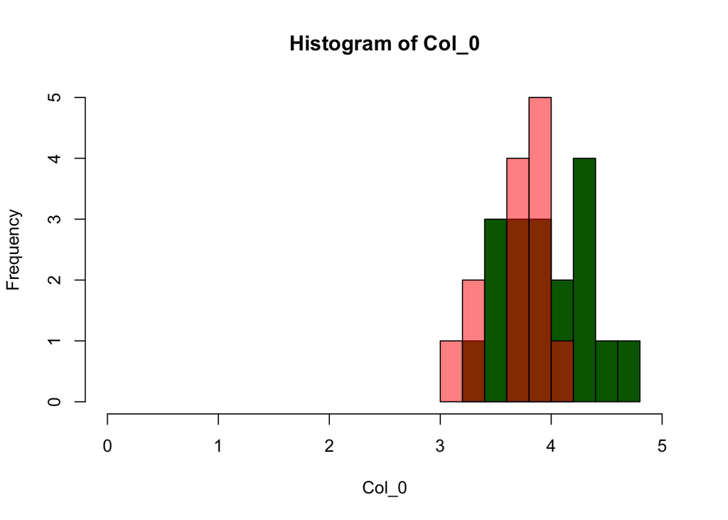

```
## La taille moyenne des plantes wild est de 3.972222 et la taille des plantes mutants est de 3.727692
```

## 2.1 Visualisation

On peut les representer par des histogrammes.

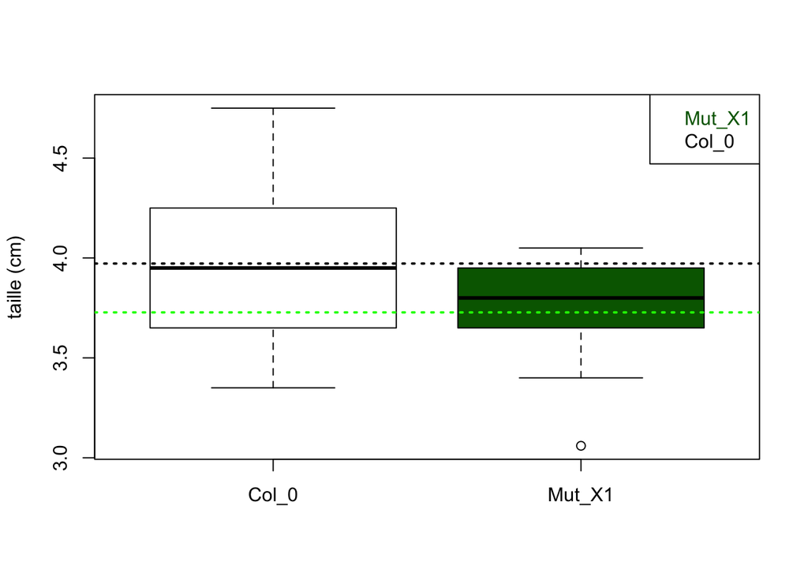

```r
# Représentation graphique des données
boxplot(Col_0,Mut_X1,names=c("Col_0","Mut_X1"),col=c("white","darkgreen"),ylab="taille (cm)")
abline(h=mean(Col_0),col="black",lty=3,lwd=2)
abline(h=mean(Mut_X1),col="green",lty=3,lwd=2)
legend("topright", legend = c("Mut_X1","Col_0" ), text.col = c("darkgreen","black"))
```

Mais aussi avec des boxplots. On observe une plus grande dispersion chez les groupe Col_0.

## Test d’adéquation à la loi normale (H0 = “les données suivent la loi Normale”)

```r
shapiro.test(Col_0)
```

```
##
##  Shapiro-Wilk normality test
##
## data:  Col_0
## W = 0.9701, p-value = 0.7996
```

```r
shapiro.test(Mut_X1)
```

```
##
##  Shapiro-Wilk normality test
##
## data:  Mut_X1
## W = 0.88924, p-value = 0.09525
```

Normalité : p-value > 0.05 → pas de rejet → données normales.

```r
var.test(Col_0, Mut_X1) # On teste l'homogénéité de la variance.
```

```
##
##  F test to compare two variances
##
## data:  Col_0 and Mut_X1
## F = 1.7592, num df = 17, denom df = 12, p-value = 0.3234
## alternative hypothesis: true ratio of variances is not equal to 1
## 95 percent confidence interval:
##  0.5622863 4.9695146
## sample estimates:
## ratio of variances
##           1.759191
```

Variances : p-value = 0.32 > 0.05 → homogénéité supposée.

Les 2 series suivent une loi normal car les 2 p value sont superieures à 0.05 donc on accepte H0.

rmq : cela dépend de l’échantillon et du degré de liberté. On a une p-value de 0.3234 donc on accepte H0.

On peut passer au test de comapraison des moyennes. # Test d’homogénéité (de comparaison) des moyennes (H0 = “les moyennes sont égales”)

```r
t.test(Col_0,Mut_X1,var.equal = T)
```

```
##
##  Two Sample t-test
##
## data:  Col_0 and Mut_X1
## t = 1.9173, df = 29, p-value = 0.0651
## alternative hypothesis: true difference in means is not equal to 0
## 95 percent confidence interval:
##  -0.01631732  0.50537715
## sample estimates:
## mean of x mean of y
##  3.972222  3.727692
```

```r
t.test(Col_0,Mut_X1,var.equal = T, alternative = "greater")
```

```
##
##  Two Sample t-test
##
## data:  Col_0 and Mut_X1
## t = 1.9173, df = 29, p-value = 0.03255
## alternative hypothesis: true difference in means is greater than 0
## 95 percent confidence interval:
##  0.02782437        Inf
## sample estimates:
## mean of x mean of y
##  3.972222  3.727692
```

```r
t.test(Col_0,Mut_X1,var.equal = T, alternative = "less")
```

```
##
##  Two Sample t-test
##
## data:  Col_0 and Mut_X1
## t = 1.9173, df = 29, p-value = 0.9675
## alternative hypothesis: true difference in means is less than 0
## 95 percent confidence interval:
##       -Inf 0.4612355
## sample estimates:
## mean of x mean of y
##  3.972222  3.727692
```

Bilatéral : p-value > 0.05 → pas de différence significative. Unilatéral (Col > Mut) : p-value < 0.05 → Col significativement plus grand.

**Conclusion.** La tendance suggère que la mutation pourrait réduire la croissance, mais la significativité dépend du type de test choisi (bilatéral vs unilatéral).

Les hypothese alternatives on peut chosiir qu’elle soit unilatérale ou bilatérale. Mais ce choix doit être fait a priori et pas a posteriori.

# Test non paramétriques d’homogénéité (sur une variable quantitative)

```r
non_infected=c(0.021,0.15,0.023,0.03,0.022,0.05,0.035,0.1,0.03)
infected=c(1.22,1.12,1.06,1.04,0.86,1.24,1.96,0.9,2.5)
mean(non_infected)
```

```
## [1] 0.05122222
```

```r
mean(infected)
```

```
## [1] 1.322222
```

## Test d’adéquation à la loi normale

**Test de Shapiro**

```r
shapiro.test(infected)
```

```
##
##  Shapiro-Wilk normality test
##
## data:  infected
## W = 0.77769, p-value = 0.01133
```

```r
shapiro.test(non_infected)
```

```
##
##  Shapiro-Wilk normality test
##
## data:  non_infected
## W = 0.72241, p-value = 0.002591
```

On rejette l’hypothese nulle. Les distributions ne suivent pas une loi normale. **Test de Mann & Whitney (équivalent non paramétrique du test de Student)**

```r
wilcox.test(infected,non_infected)                        # bilatéral
```

```
##
##  Wilcoxon rank sum test with continuity correction
##
## data:  infected and non_infected
## W = 81, p-value = 0.0004095
## alternative hypothesis: true location shift is not equal to 0
```

```r
wilcox.test(infected,non_infected,alternative="greater")  # unilatéral
```

```
##
##  Wilcoxon rank sum test with continuity correction
##
## data:  infected and non_infected
## W = 81, p-value = 0.0002047
## alternative hypothesis: true location shift is greater than 0
```

Normalité : non respectée (p-value < 0.05). Mann–Whitney : p-value très faible → rejet de H0.

**Conclusion**. Le gène est significativement plus exprimé chez les plantes infectées.